# Utilisation de Strava chez les coureurs amateurs

Quels impacts psychosociaux et quels impacts sur la pratique ?

Laura Costa - MASTER M1 STAPS UGA (ATDM)

Mars 2025

# Présentation de l’étude

### Thématique

Strava est un réseau social créé en **2009** qui permet d’enregistrer et de partager ses activités sportives à un réseau d’abonnés. Strava regroupe plus de **135 millions d’utilisateurs en 2024** dans plus de 190 pays <sup>1</sup>. 40 millions d’activités sont téléchargées chaque semaine. En 2023, la course à pied est le sport où le plus d’activités sont téléchargées<sup>2</sup>. Le réseau social propose différentes fonctionnalités : enregistrement des activités, suivi des progrès, encouragements(kudos), partage des activités, clubs… Le réseau social a également un important aspect de gamification avec les segments, les KOM/QOM, les Local Legends… En tant que réseau social dédié aux sportifs, et notamment aux coureurs amateurs, Strava permet aux utilisateurs d’entrer en interaction et de se comparer aux autres utilisateurs. Dans la communauté des utilisateurs se développe alors cette phrase, reprise par Strava <sup>1</sup> (“Strava or it didn’t happen) :

> *” Si ce n’est pas sur Strava, ça n’existe pas.”*

Le but de l’étude est de savoir si **l’utilisation de Strava a des impacts psychosociaux chez les coureurs amateurs et si elle a une influence sur la pratique (kilomètres parcourus par semaine, nombre d’entraînements par semaine, nombre de compétitions par an).**

### Problématique

L’étude de Russell (2023) <sup>3</sup> met en avant les implications psychosociales de l’utilisation de Strava auprès de coureurs de clubs universitaires à travers les Etats-Unis. Des entretiens semi-structurés ont permis de mettre en avant trois thèmes principaux : **la présentation de soi, la pression sociale et la motivation**.

L’étude présente réalisée dans le cadre de mon master STAPS s’intéresse à l’impact de l’utilisation de Strava sur les coureurs amateurs : elle s’adresse à un public plus large que l’étude de Russell (coureurs amateurs utilisateurs de Strava) et se fonde sur un questionnaire de 84 questions obligatoires. Cette étude cherche à quantifier l’utilisation de Strava, à caractériser la manière de se présenter sur Strava, à identifier si Strava est une source de motivation et/ou de stress et à identifier si l’utilisation de Strava impacte la pratique.

Ainsi, la problématique de l’étude présente est la suivante :

**Quels sont les impacts psychosociaux de l’utilisation de Strava chez les coureurs amateurs et dans quelle mesure l’utilisation de ce réseau social a des impacts sur la pratique de la course à pied ?**

Cette étude porte sur plusieurs questions de recherche :

- L’utilisation de Strava impacte-t-elle la pratique des coureurs amateurs ?
- Comment les coureurs amateurs se présentent-ils sur Strava ?
- Est-ce que l’utilisation de Strava peut être une source de stress ?
- Est-ce que l’utilisation de Strava peut être une source de motivation ?

### Hypothèses

**Hypothèse 1** Plus les coureurs amateurs utilisent Strava, plus le nombre de kilomètres et d’entraînements par semaine, et le nombre de compétitions par an sont élevés.

**Hypothèse 2 :** Plus les coureurs amateurs utilisent Strava, plus ils sont susceptibles de filtrer ou modifier ce qu’ils partagent pour contrôler leur image.

**Hypothèse 3 :** Plus les coureurs amateurs utilisent Strava, plus ils sont susceptibles de ressentir du stress.

**Hypothèse 4 :** Plus les coureurs amateurs utilisent Strava, plus ils sont motivés dans leur pratique.

### Méthode

Le questionnaire a été construit suite à la lecture de différents articles, notamment l’étude de Russell (2023)<sup>3</sup> qui s’intéresse aux implications psychosociales de l’utilisation de Strava chez des coureurs universitaires aux Etats-Unis, l’étude d’Evans (2019)<sup>4</sup> qui s’intéresse aux sources de motivation chez les coureurs et la thèse de Chapman (2024)<sup>5</sup> qui examine l’impact de l’utilisation de Strava et de la comparaison sociale sur le bien-être, l’épuisement sportif et le plaisir du sport chez de jeunes coureurs non-élites. L’étude d’Evans se base sur un questionnaire en ligne auprès de 25 000 coureurs de 7 pays, l’étude de Chapman se base sur un questionnaire en ligne également diffusé auprès de 200 coureurs et l’étude de Russell se base sur des entretiens semi-structurés auprès de 18 coureurs.

En partant de ces 3 articles, d’autres articles sont venus compléter la création du questionnaire afin d’avoir des échelles psychométriques pour mesurer la présentation de soi, la pression sociale et la motivation<sup>67</sup>.

Le questionnaire a été construit de sorte d’avoir moins de 100 questions et une durée de passation de moins de 10 minutes afin de ne pas décourager les répondants et d’éviter que les réponses aux dernières questions soient faussées car les répondants répondent sans réfléchir pour terminer au plus vite.

Le questionnaire a été validée par notre enseignante à l’UGA avant diffusion. Le questionnaire comportait 84 questions : toutes les questions étaient obligatoires, sauf les questions comportant la mention “si oui”. La durée de passation était estimée à 10 minutes. Les critères d’inclusion étaient d’être un **coureur amateur utilisateur de Strava et avoir plus de 18 ans**. Le questionnaire était totalement **anonyme**.

Le questionnaire a été diffusé sur les réseaux sociaux : mon compte personnel LinkedIn, mon compte personnel Strava et dans les groupes Facebook “Bref, je fais du trail”, “Coeur de runneuses”, et “Courir après 50 ans”. Le questionnaire a également été diffusé auprès de 2 clubs de course à pied : ACP Crolles et AL Echirolles. Le questionnaire a été ouvert du **28 janvier au 12 février 2025**.

Les données ont été récupérées sous Excel, pour faire un premier traitement (suppression des valeurs non exploitables et formatage de certaines valeurs (exemple : ancienneté pratique : “10 ans” > “10”)). Les analyses ont été réalisées avec R (avec les librairies tidyverse, vcd et psy) Dans la base de données, chaque ligne représente un coureur et chaque colonne une variable.

Les mesures réalisées sont les suivantes : - Données socio-démographiques : âge, sexe, catégorie socio-professionnelle - Données d’utilisation de Strava : - Intensité d’utilisation de Strava : Facebook Intensity Scale > Strava Intensity Scale (Elison, 2007<sup>8</sup> et Ross, 2009<sup>9</sup>) - Utilisation des fonctions de sociabilité en ligne : Online Sociability Functions (Ross, 2019<sup>9</sup>) - Exposition des informations personnelles : Facebook Scale > Strava Scale (Ross, 2019<sup>9</sup>) - Compléments : but d’utilisation de Strava, fonctionnalité la plus appréciée… - Quantification de la pratique : ancienneté, niveau, nombre de kilomètres et d’entraînements par semaine, nombre de compétitions par an, lieu et mode de pratique… - Mesure de l’auto-présentation sur Strava : Self-presentation and Upward Social Comparison Inclination Scale (Hjetland, 2022<sup>10</sup> et Hjetland, 2024<sup>17</sup>) - Mesure du stress perçu par l’utilisation de l’application : Perceived Stress Scale (Chiu, 2016<sup>11</sup>) - Mesure de la motivation à courir : Behavioural Regulation In Exercise Questionnaire 3-12 items (Rocchi, 2023<sup>12</sup>)

# Données socio-démographiques

[output not shown]

```
## La moyenne d'âge est de 39.9261744966443 ans, avec un écart-type de 11.3338238902361 ans.
```

```
## La catégorie socio-professionelle la plus représentée est Cadres et professions intellectulles, qui représente 44.9664429530201 % de l'échantillon, puis les employés avec 25.6375838926174 %.
```

### Âge et sexe

#### Répartition de l’âge

| Moyenne | Médiane | Ecart_type |
| --- | --- | --- |
| 39.92617 | 38 | 11.33382 |

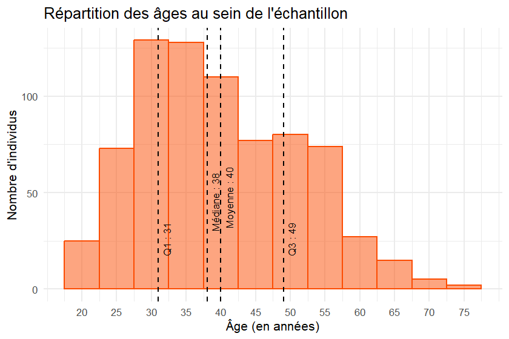

#### Répartition des sexes

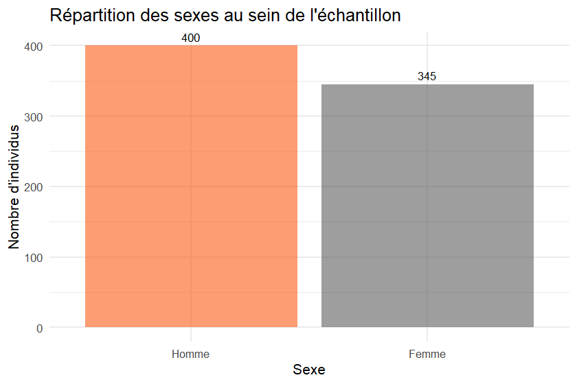

#### Répartition de l’âge en fonction des sexes

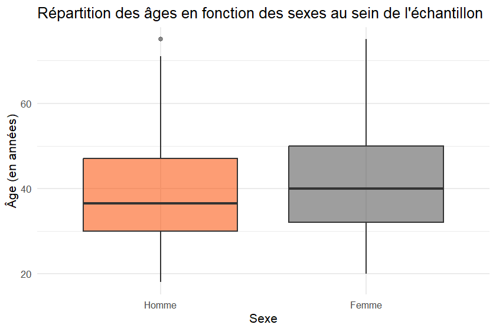

### Catégories socio-professionnelles

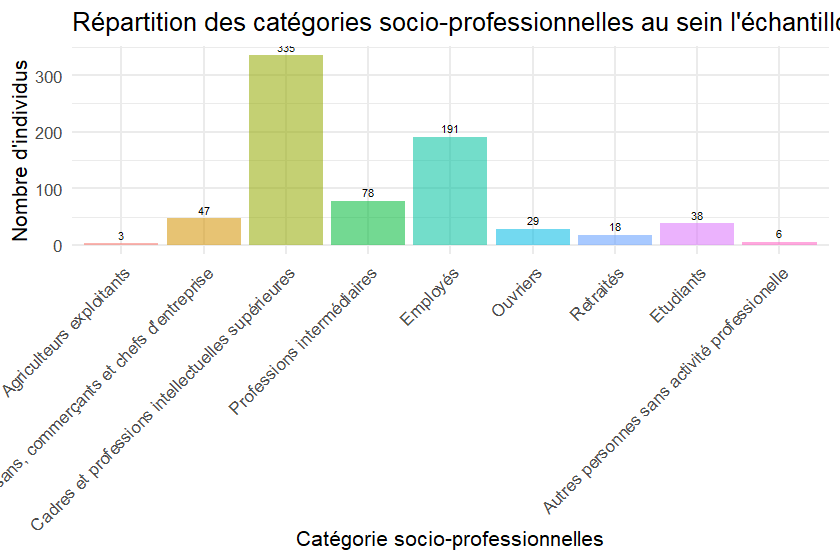

# Utilisation de Strava

### Mesure de l’intensité d’utilisation

Les questions 20 à 24 (Echelle de Linkert) sont issues d’une traduction et adaptation du Facebook Intensity Scale, utilisé dans l’étude d’Ellison <sup>8</sup> et repris dans l’étude de Ross (2009)<sup>9</sup>, en remplaçant “Facebook” par “Strava”. Il y a donc **5 items** pour cette échelle de mesure adaptée pour identifier à quel point l’utilisation de Strava fait partie du quotidien de l’utilisateur. Cette échelle est renommée pour l’étude en Strava Intensity Scale (SIS).

L’alpha de Cronbach dans l’étude d’Ellison (2007) est de 0.83 <sup>8</sup> et de 0.85 dans l’étude de Ross (2009) <sup>9</sup>.

Un score bas au SIS indique que Strava fait peu partie du quotidien de l’utilisateur et qu’il y est peu attaché tandis qu’un score haut au SIS indique que l’utilisateur utilise Strava très fréquemment et est affecté négativement s’il ne peut pas l’utiliser.

```
## L'alpha de Cronbach sur les 5 items est de 0.763630836835257.
```

L’alpha de Cronbach est acceptable.

#### SIS 1

| Moyenne | Médiane | Ecart_type |
| --- | --- | --- |
| 2.887248 | 3 | 1.048891 |

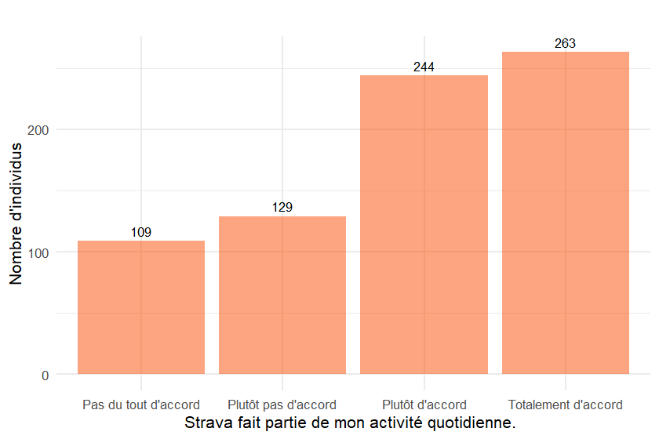

#### SIS 2

| Moyenne | Médiane | Ecart_type |
| --- | --- | --- |
| 2.283221 | 2 | 1.018142 |

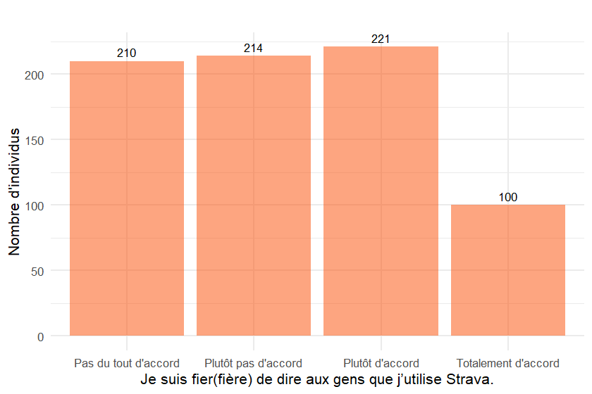

#### SIS 3

| Moyenne | Médiane | Ecart_type |
| --- | --- | --- |
| 1.861745 | 2 | 0.9635562 |

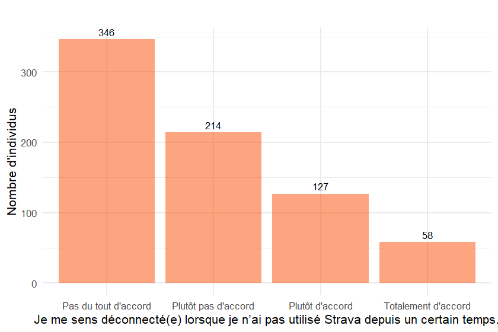

#### SIS 4

| Moyenne | Médiane | Ecart_type |
| --- | --- | --- |
| 2.324832 | 2 | 1.028747 |

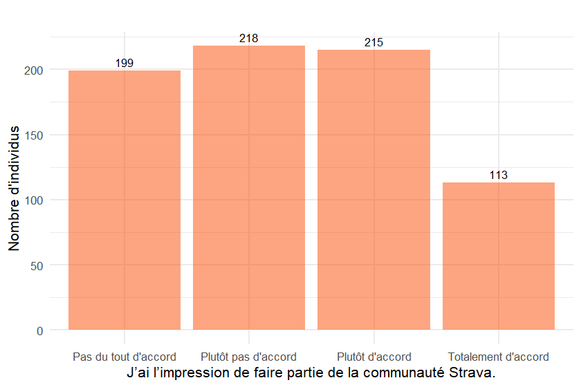

#### SIS 5

[output not shown]

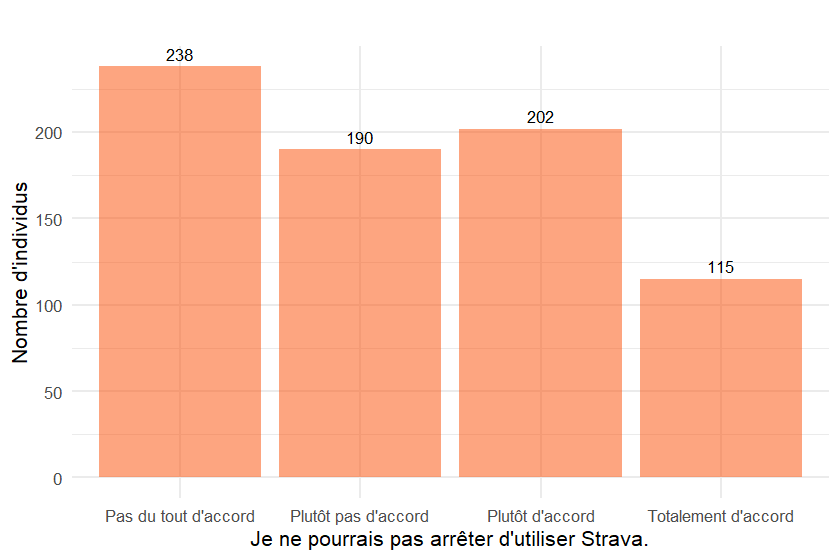

#### SCORE SIS

| Variable | Moyenne | Médiane | Ecart_type |
| --- | --- | --- | --- |
| SIS1 | 2.887248 | 3 | 1.0488914 |
| SIS2 | 2.283221 | 2 | 1.0181421 |
| SIS3 | 1.861745 | 2 | 0.9635562 |
| SIS4 | 2.324832 | 2 | 1.0287472 |
| SIS5 | 2.260403 | 2 | 1.0685395 |
| Total | 11.617450 | 11 | 3.6786169 |

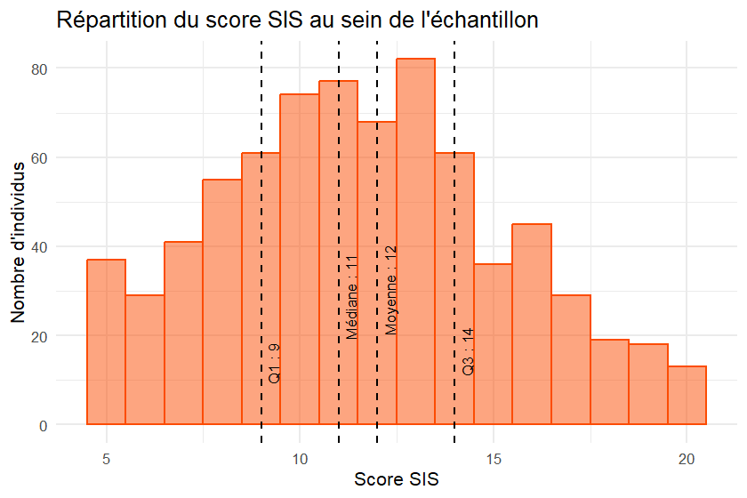

### Compléments

#### Fréquence de publication

| Moyenne | Médiane | Ecart_type |
| --- | --- | --- |
| 4.019595 | 4 | 1.751847 |

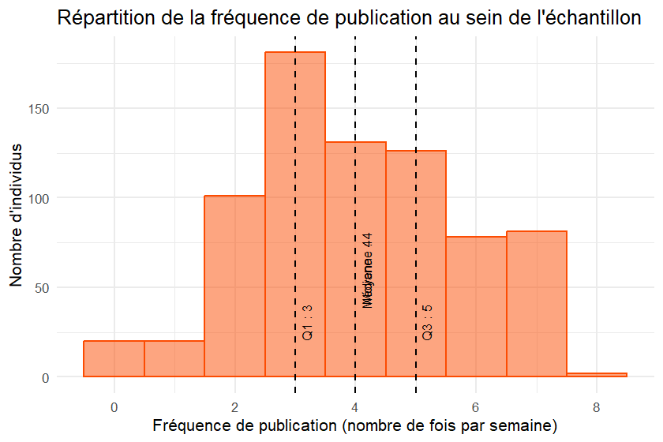

#### Fréquence de consultation

| Moyenne | Médiane | Ecart_type |
| --- | --- | --- |
| 5.148448 | 6 | 2.159883 |

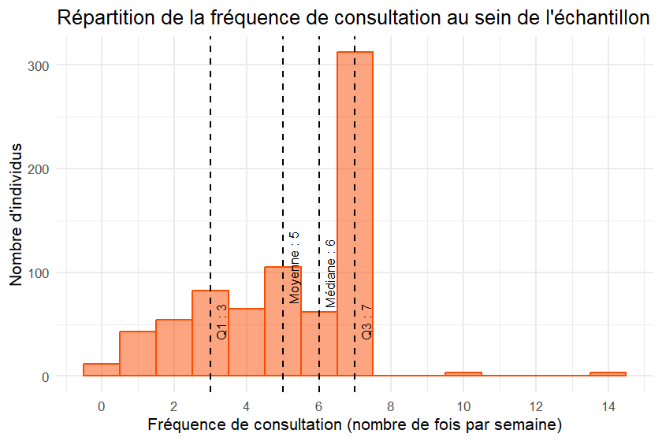

#### Nombre d’abonnés

| Médiane | Moyenne | Ecart_type |
| --- | --- | --- |
| 40 | 68.49324 | 94.93197 |

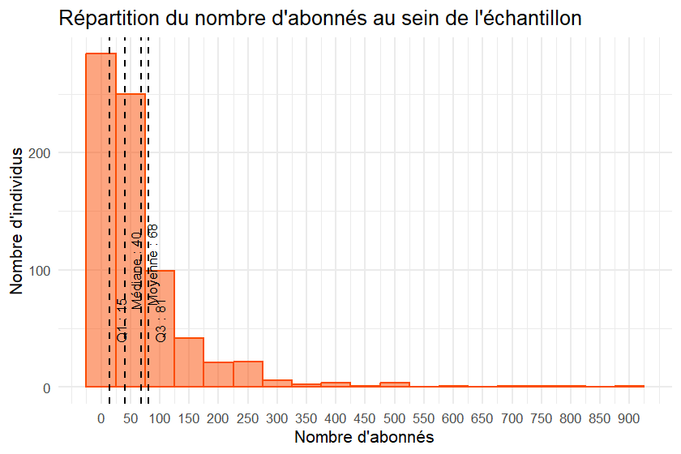

#### Nombre d’abonnements

| Médiane | Moyenne | Ecart_type |
| --- | --- | --- |
| 40 | 68.32206 | 80.03015 |

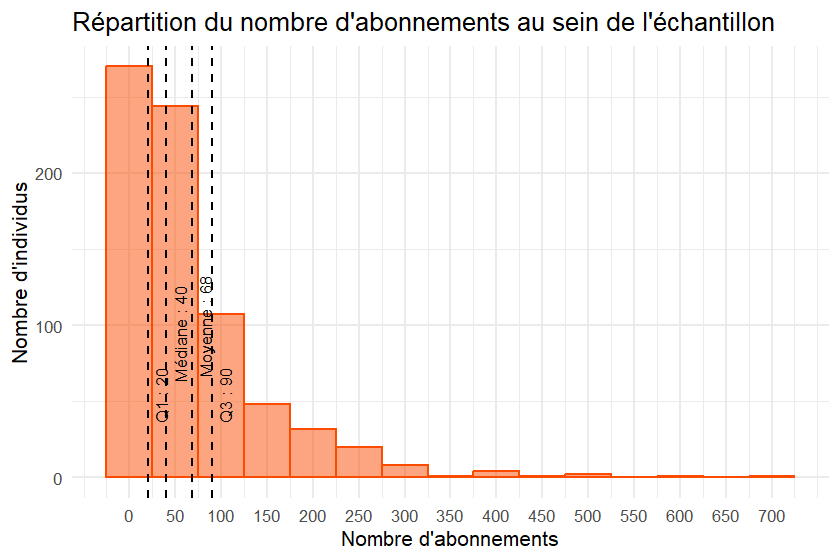

### Mesure de la sociabilité en ligne

Les questions 39 à 42 (Echelle de Linkert) sont une traduction et adaptation du Online Sociability Functions (OSF) utilisé dans l’étude de Ross (2009)<sup>9</sup> qui mesure la sociabilité en ligne. L’alpha de Cronbach dans l’étude de Ross (2009)<sup>9</sup> est de 0.74. Il y a donc **4 items** pour cette échelle de mesure adaptée pour identifier à quel point chaque utilisateur est sociable sur Strava.

On pourrait ajouter le nombre de clubs Strava dont l’utilisateur fait partie (question 38) et le nombre de kudos reçus (question 42) pour enrichir cette échelle mais cela ne modifie quasiment pas l’alpha de Cronbach.

Un score bas au OSF indique que l’utilisateur utilise peu les fonctionnalités de sociabilité en ligne, tandis qu’un score haut indique que l’utilisateur utilise beaucoup de fonctionnalités de sociabilité en ligne.

```
## L'alpha de Cronbach sur les 4 items est de 0.601301166919539.
```

L’alpha de Cronbach est un peu faible, cela peut s’expliquer par le fait qu’il s’agit d’une traduction et adaptation du questionnaire d’origine dans le cadre de cette étude.

#### Kudos donnés

| Moyenne | Médiane | Ecart_type |
| --- | --- | --- |
| 3.50604 | 4 | 0.7461576 |

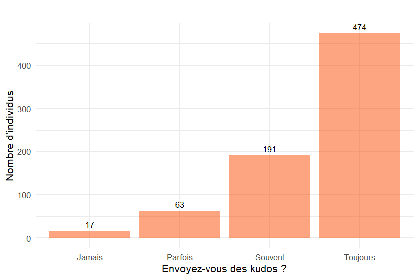

#### Commentaires donnés

| Moyenne | Médiane | Ecart_type |
| --- | --- | --- |
| 2.175839 | 2 | 0.6537373 |

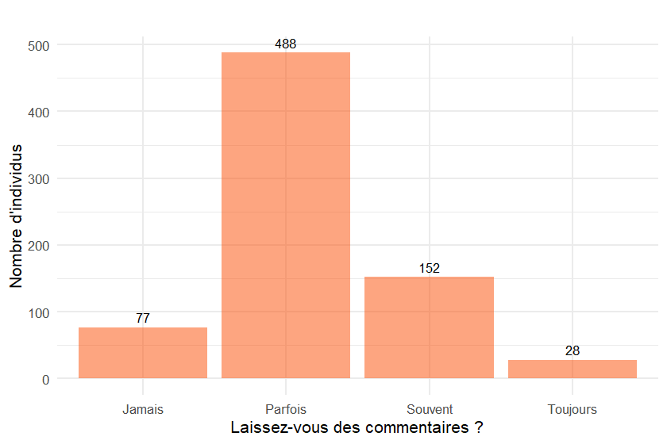

#### Publications

| Moyenne | Médiane | Ecart_type |
| --- | --- | --- |
| 1.103356 | 1 | 0.3757459 |

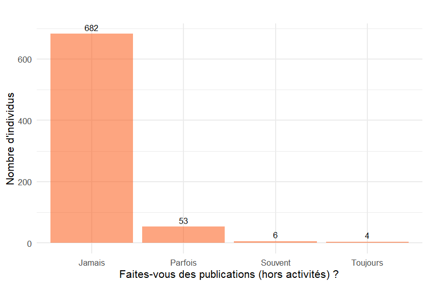

#### Commentaires reçus

| Moyenne | Médiane | Ecart_type |
| --- | --- | --- |
| 2.256376 | 2 | 0.6091068 |

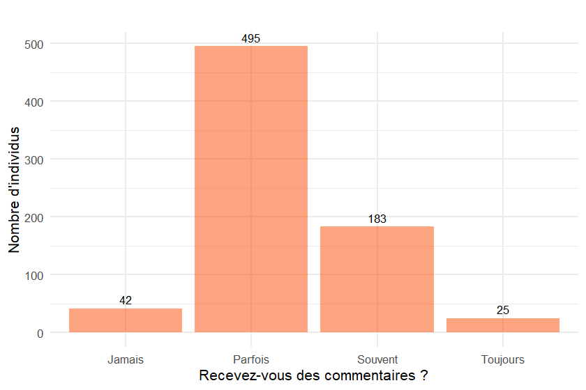

#### SCORE OSF

| Variable | Moyenne | Médiane | Ecart_type |
| --- | --- | --- | --- |
| Kudos donnés | 3.506040 | 4 | 0.7461576 |
| Commentaires donnés | 2.175839 | 2 | 0.6537373 |
| Commentaires reçus | 2.256376 | 2 | 0.6091068 |
| Publications | 1.103356 | 1 | 0.3757459 |
| Total | 9.041611 | 9 | 1.6508836 |

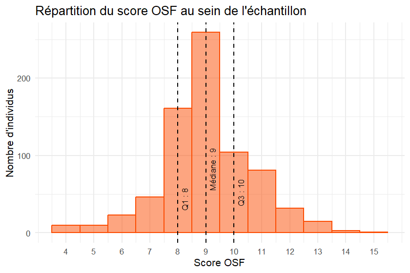

### Compléments

#### Clubs Strava

| Moyenne | Médiane | Ecart_type |
| --- | --- | --- |
| 2.674003 | 1 | 5.03045 |

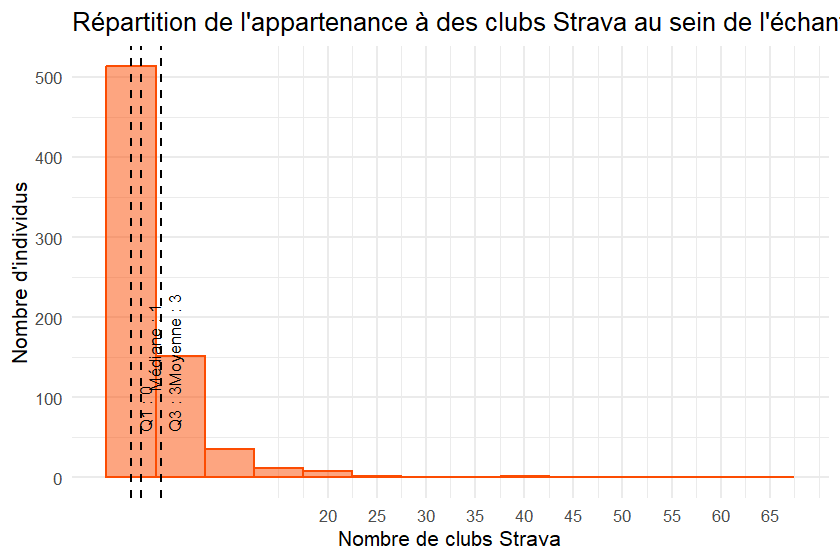

#### Nombre de kudos reçus

| Moyenne | Médiane | Ecart_type |
| --- | --- | --- |
| 16.00808 | 10 | 15.22305 |

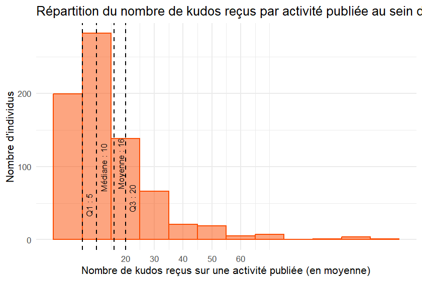

### Mesure de l’exposition

Les questions 25 à 28 (Echelle de Linkert) sont un extrait, une traduction et adaptation du Facebook questionnaire utilisé dans l’étude de Ross (2009)<sup>9</sup>. Dans l’étude de Ross (2009), il n’est pas mentionné que ces items mesurent le niveau d’exposition. Dans l’étude présente, une échelle est donc créée pour mesurer le niveau d’exposition sur Strava (SCORE EXPOSITION). Il y a donc **10 items** pour cette échelle de mesure adaptée pour identifier à quel point chaque utilisateur expose des informations personnelles sur Strava.

Un score bas indique l’utilisateur partage peu d’informations personnelles avec une restriction de public tandis qu’un score indique l’utilisateur partage beaucoup d’informations personnelles sans restriction de public.

```
## L'alpha de Cronbach sur les 10 items est de 0.78033975325236.
```

L’alpha de Cronbach est acceptable.

#### Activités

| Moyenne | Médiane | Ecart_type |
| --- | --- | --- |
| 2.421476 | 2 | 0.5482822 |

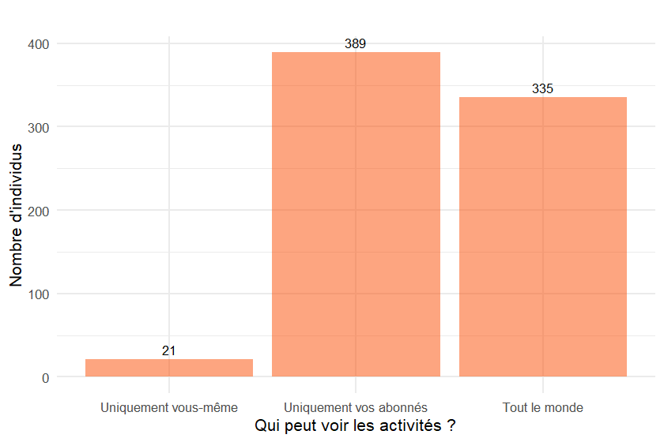

#### Horaires

| Moyenne | Médiane | Ecart_type |
| --- | --- | --- |
| 2.32349 | 2 | 0.6275903 |

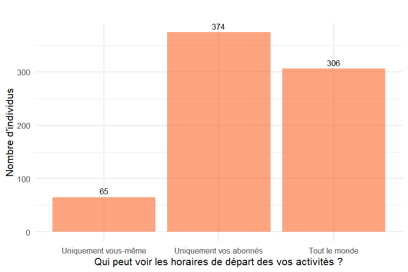

#### Fréquence cardiaque

| Moyenne | Médiane | Ecart_type |
| --- | --- | --- |
| 2.151678 | 2 | 0.7583411 |

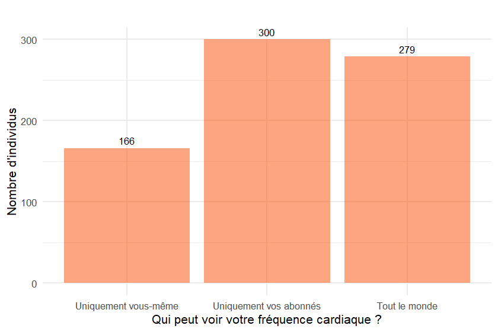

#### Allure

| Moyenne | Médiane | Ecart_type |
| --- | --- | --- |
| 2.365101 | 2 | 0.6031867 |

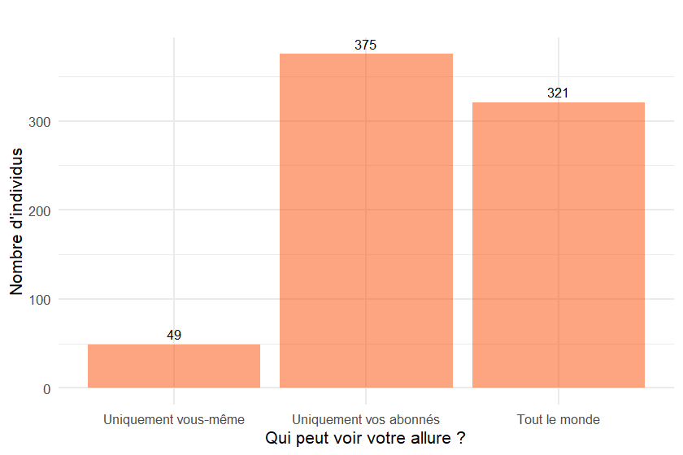

#### Carte

| Moyenne | Médiane | Ecart_type |
| --- | --- | --- |
| 1.851007 | 2 | 0.8250625 |

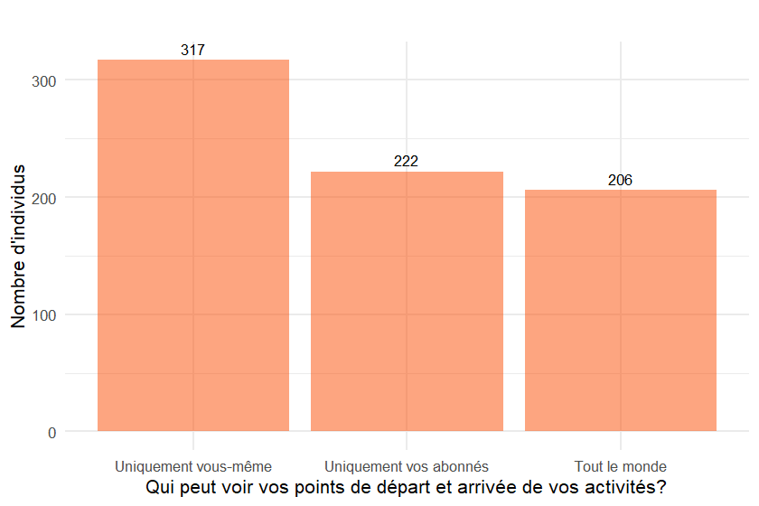

#### Publication entraînement

| Moyenne | Médiane | Ecart_type |
| --- | --- | --- |
| 3.528859 | 4 | 0.7438182 |

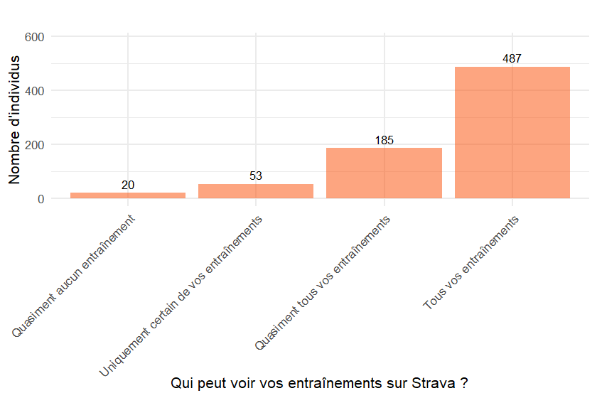

#### Publication compétition

| Moyenne | Médiane | Ecart_type |
| --- | --- | --- |
| 3.719463 | 4 | 0.7552396 |

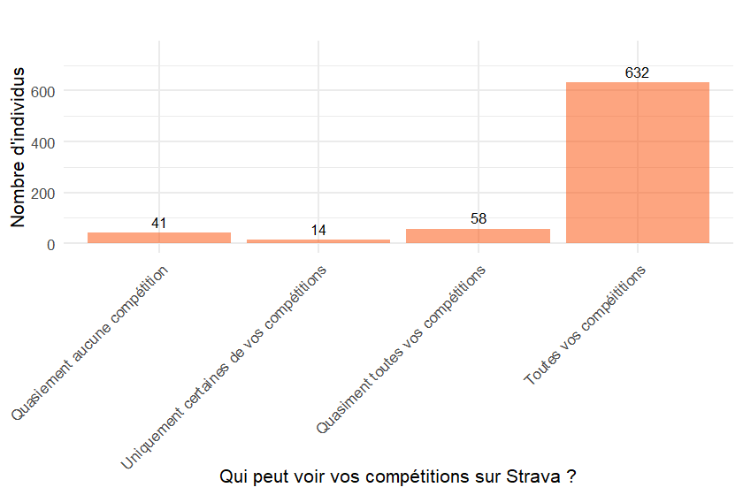

#### Nommage activité

| Moyenne | Médiane | Ecart_type |
| --- | --- | --- |
| 2.775235 | 3 | 0.968134 |

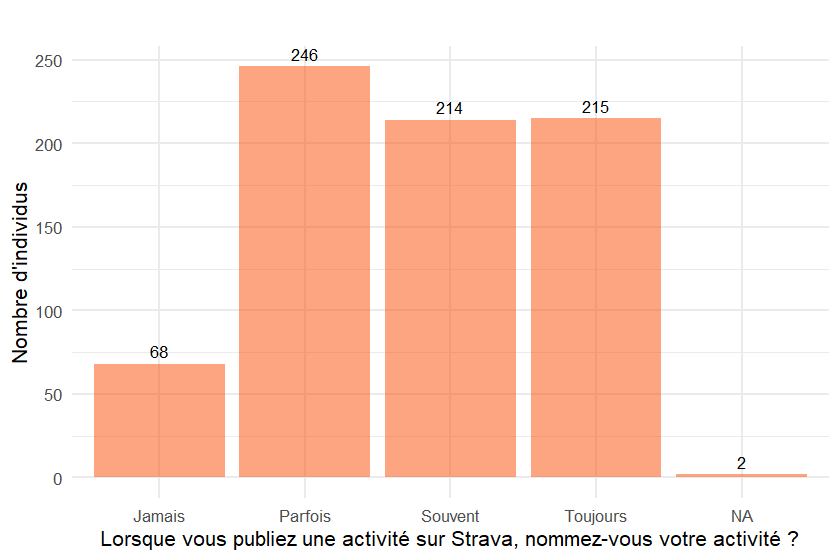

#### Commentaire activité

| Moyenne | Médiane | Ecart_type |
| --- | --- | --- |
| 2.259758 | 2 | 0.8506116 |

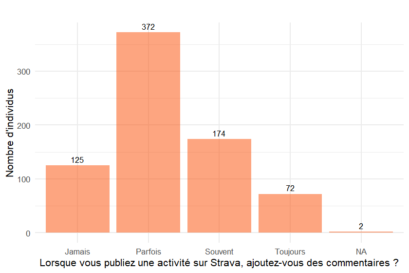

#### Photo activité

| Moyenne | Médiane | Ecart_type |
| --- | --- | --- |
| 2.252022 | 2 | 0.6871404 |

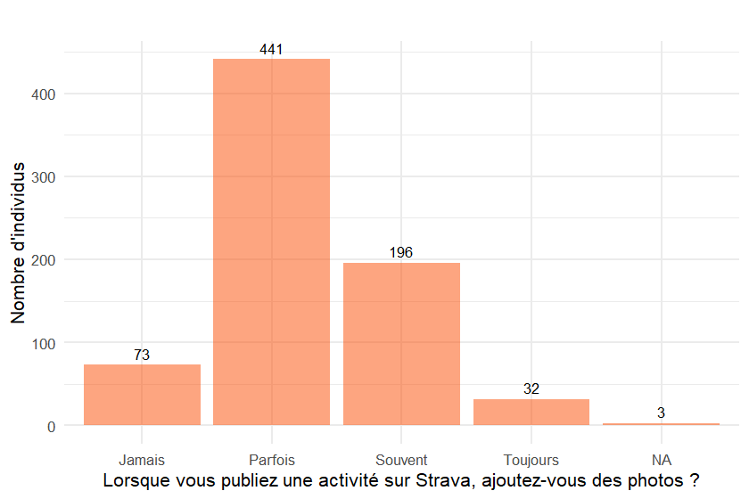